# Income Inequality vs Index of Health and Social Problems : US

coop711

2016-10-07

### Data Reading

```r
library(knitr)
# library(xlsx)
# data.usa <- read.xlsx("../data/USA-inequality.xls", 1, stringsAsFactors = FALSE)
load("./Inequality_Index_HS_US.RData")
str(data.usa)
```

```
## 'data.frame':    50 obs. of  20 variables:
##  $ State                            : chr  "Alabama" "Alaska" "Arizona" "Arkansas" ...
##  $ State.Abbrev                     : chr  "AL" "AK" "AZ" "AR" ...
##  $ Income.Inequality                : num  0.475 0.402 0.45 0.458 0.475 ...
##  $ Trust                            : num  23 NA 47 29 43 46 49 NA 37 38 ...
##  $ Life.expectancy                  : num  74.6 76.7 77.5 75.1 78.3 ...
##  $ Infant.mortality                 : num  9.1 5.5 6.4 8.3 5.5 ...
##  $ Obesity                          : num  32 30 28.5 31 31 21.5 26.5 27 27.5 30.5 ...
##  $ Mental.health                    : num  3.3 2.8 2.2 3.2 3.3 ...
##  $ Maths.and.literacy.scores        : num  258 268 263 262 259 ...
##  $ Teenage.births                   : num  62.9 42.4 69.1 68.5 48.5 ...
##  $ Homicides                        : num  78.9 85.6 80.4 56.1 60.5 ...
##  $ Imprisonment                     : num  509 413 507 415 478 357 372 429 447 502 ...
##  $ Index.of.health...social.problems: num  1.385 0.137 0.212 0.948 0.327 ...
##  $ Overweight.children              : num  35 31 30 33 30 22 27 35 32 32 ...
##  $ Child.wellbeing                  : num  8.5 4.4 4.9 9.3 -3.4 ...
##  $ Women.s.status                   : num  -0.932 0.74 -0.147 -1.318 0.969 ...
##  $ Juvenile.homicides               : num  12 8 7 6 10 4 4 0 NA 8 ...
##  $ High.school.drop.outs            : num  24.7 11.7 19 24.7 23.2 ...
##  $ Child.mental.illness             : num  11.5 8.2 8.7 11.8 7.5 ...
##  $ Pugnacity                        : num  41.8 NA 36.3 38.4 37.7 ...
```

당장 필요한 변수들만 모아서 data frame으로 재구성한다. 변수명 설정에 유의한다.

```r
data.usa.1 <- data.frame(Gini = data.usa$Income.Inequality,  HS.index = data.usa$Index.of.health...social.problems)
str(data.usa.1)
```

```
## 'data.frame':    50 obs. of  2 variables:
##  $ Gini    : num  0.475 0.402 0.45 0.458 0.475 ...
##  $ HS.index: num  1.385 0.137 0.212 0.948 0.327 ...
```

```r
Gini <- data.usa.1$Gini
State <- data.usa$State
Abb <- data.usa$State.Abbrev
options(digits = 3)
kable(data.frame(State = State, State.Abb = Abb, data.usa.1))
```

| State | State.Abb | Gini | HS.index |
| --- | --- | --- | --- |
| Alabama | AL | 0.475 | 1.385 |
| Alaska | AK | 0.402 | 0.137 |
| Arizona | AZ | 0.450 | 0.212 |
| Arkansas | AR | 0.458 | 0.948 |
| California | CA | 0.475 | 0.327 |
| Colorado | CO | 0.438 | -0.507 |
| Connecticut | CT | 0.477 | -0.660 |
| Delaware | DE | 0.429 | 0.133 |
| Florida | FL | 0.470 | 0.360 |
| Georgia | GA | 0.461 | 0.896 |
| Hawaii | HI | 0.434 | -0.388 |
| Idaho | ID | 0.427 | -0.429 |
| Illinois | IL | 0.456 | 0.206 |
| Indiana | IN | 0.424 | 0.370 |
| Iowa | IA | 0.418 | -0.895 |
| Kansas | KS | 0.435 | -0.442 |
| Kentucky | KY | 0.468 | 0.874 |
| Louisiana | LA | 0.483 | 1.595 |
| Maine | ME | 0.434 | -0.769 |
| Maryland | MD | 0.434 | 0.187 |
| Massachusetts | MA | 0.463 | -0.959 |
| Michigan | MI | 0.440 | 0.349 |
| Minnesota | MN | 0.426 | -1.216 |
| Mississippi | MS | 0.478 | 1.692 |
| Missouri | MO | 0.449 | 0.392 |
| Montana | MT | 0.436 | -0.906 |
| Nebraska | NE | 0.424 | -0.583 |
| Nevada | NV | 0.436 | 0.803 |
| New Hampshire | NH | 0.414 | -1.242 |
| New Jersey | NJ | 0.460 | -0.402 |
| New Mexico | NM | 0.460 | 0.564 |
| New York | NY | 0.499 | -0.179 |
| North Carolina | NC | 0.452 | 0.494 |
| North Dakota | ND | 0.429 | -1.145 |
| Ohio | OH | 0.441 | 0.058 |
| Oklahoma | OK | 0.455 | 0.494 |
| Oregon | OR | 0.438 | -0.346 |
| Pennsylvania | PA | 0.452 | -0.015 |
| Rhode Island | RI | 0.457 | -0.389 |
| South Carolina | SC | 0.454 | 0.899 |
| South Dakota | SD | 0.434 | -0.759 |
| Tennessee | TN | 0.465 | 0.788 |
| Texas | TX | 0.470 | 0.930 |
| Utah | UT | 0.410 | -0.709 |
| Vermont | VT | 0.423 | -1.183 |
| Virginia | VA | 0.449 | -0.055 |
| Washington | WA | 0.436 | -0.516 |
| West Virginia | WV | 0.468 | 0.482 |
| Wisconsin | WI | 0.413 | -0.473 |
| Wyoming | WY | 0.428 | -0.551 |

주별 Gini계수를 `barplot()`으로 비교해 보자. 전부 0.4는 넘고 0.5는 넘지 않기 때문에 차이를 살피기 위해서 y축의 범위(`ylim =`)를 조정하였다. 이때 `xpd = FALSE`가 어떤 역할을 하는지 잘 알아두자.

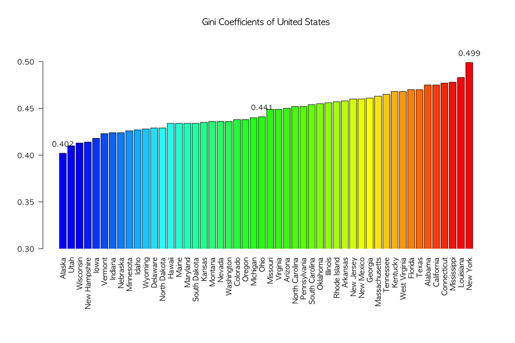

```r
par(mai = c(2.0, 0.8, 0.8, 0.4) + 0.2)
o.Gini <- order(Gini)
b.Gini <- barplot(Gini[o.Gini], names.arg = State[o.Gini], col = rev(rainbow(50, start = 0, end = 4/6)), ylim = c(0.3, 0.52), xpd = FALSE, las = 2)
text(x = b.Gini[c(1, 25, 50)], y = Gini[o.Gini][c(1, 25, 50)] + 0.01, labels = format(Gini[o.Gini][c(1, 25, 50)], digits = 3))
title(main = "Gini Coefficients of United States")
```

간단한 산점도를 그리고, 추가 작업을 생각한다.

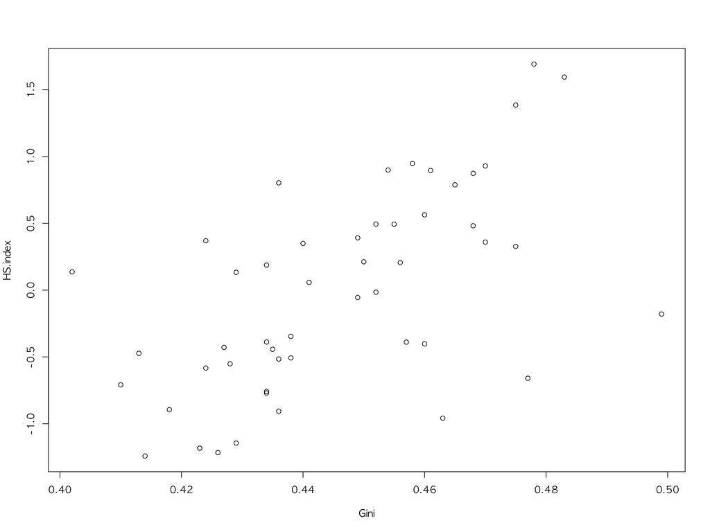

```r
plot(data.usa.1)
```

x-축과 y-축의 범위를 설정하고, `pch = 20`으로 다시 그린다.

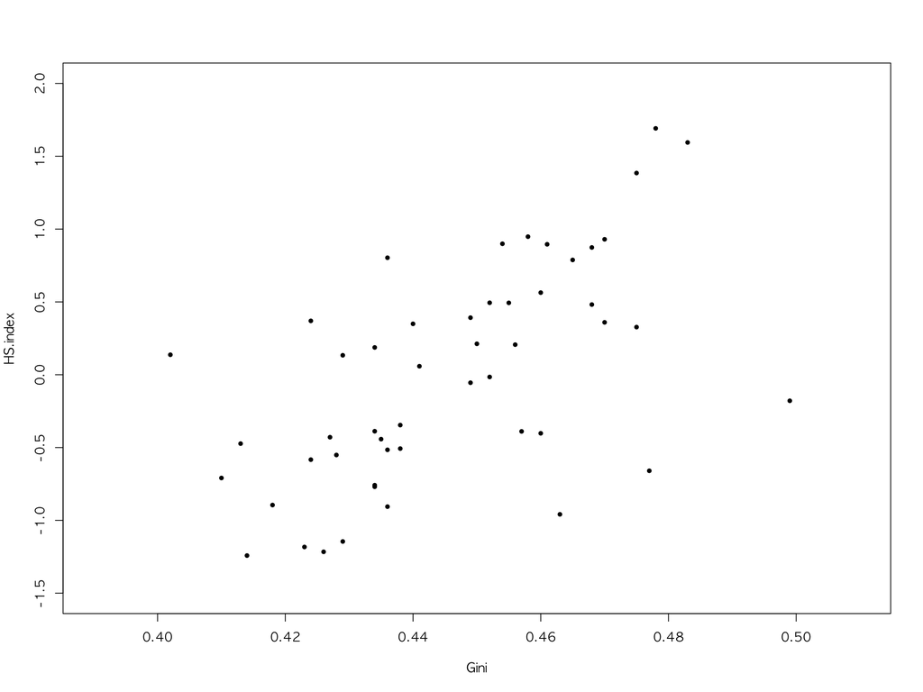

```r
plot(data.usa.1, pch = 20, xlim = c(0.39, 0.51), ylim = c(-1.5, 2.0))
```

각 주의 약칭을 새겨넣는다.

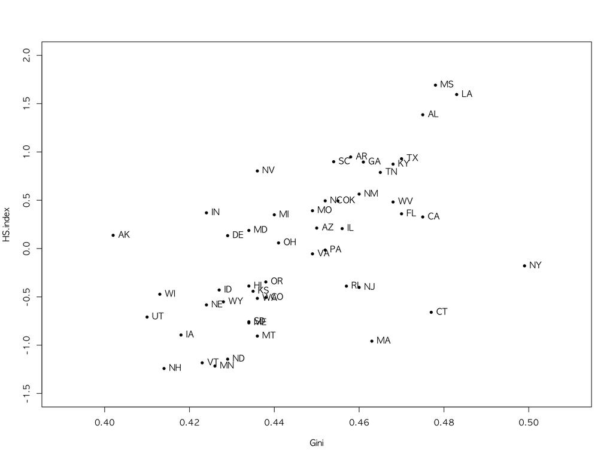

```r
plot(data.usa.1, pch = 20, xlim = c(0.39, 0.51), ylim = c(-1.5, 2.0))
text(data.usa.1, labels = Abb, pos = 4)
```

겹쳐보이는 주의 약칭들로부터 인덱스를 추출한다.

```r
which(Abb %in% c("VT", "ME", "NE", "WA", "VA", "HI", "RI", "SC", "AR", "NC", "GA", "KY"))
```

```
##  [1]  4 10 11 17 19 27 33 39 40 45 46 47
```

점 왼쪽에 약칭을 넣을 주들의 인덱스를 저장한다. 나머지 인덱스는 오른쪽에 넣을 것으로 따로 저장한다.

```r
text.left.us <- which(Abb %in% c("VT", "ME", "NE", "WA", "VA", "HI", "RI", "SC", "AR", "NC", "GA", "KY"))
text.right.us <- setdiff(1:nrow(data.usa.1), text.left.us)
pos.text.us <- ifelse(1:nrow(data.usa.1) %in% text.left.us, 2, 4)
```

왼쪽, 오른쪽 위치를 조정한 주 약칭을 다시 넣는다.

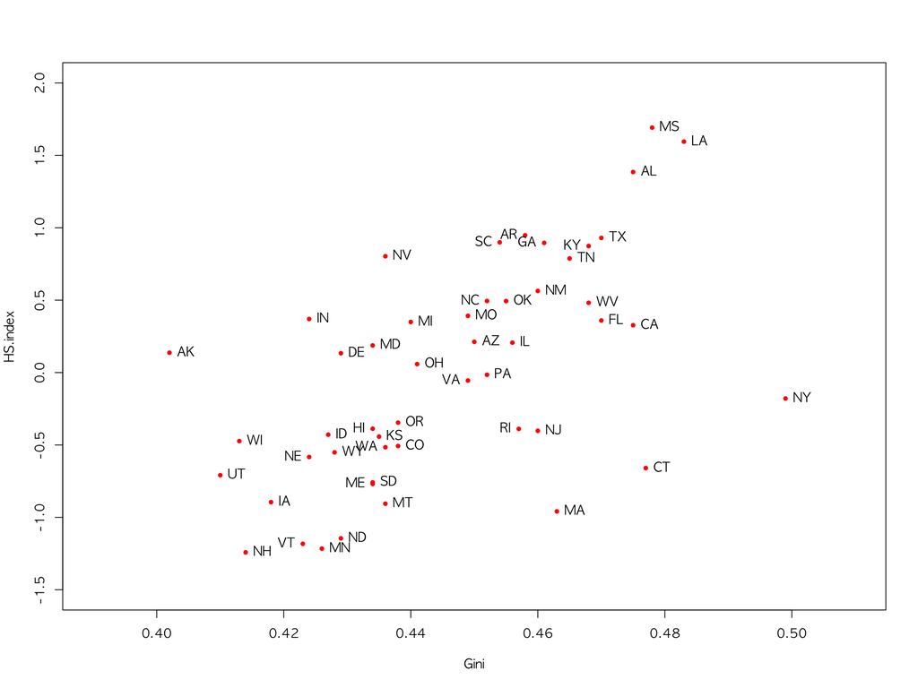

```r
plot(data.usa.1, pch = 20, col = "red", xlim = c(0.39, 0.51), ylim = c(-1.5, 2.0))
text(data.usa.1, labels = Abb, pos = pos.text.us)
```

점 아래에 약칭을 넣을 주들의 인덱스를 찾는다. 왼쪽 인덱스, 오른쪽 인덱스에서 조정한다.

```r
text.down.us <- which(Abb %in% c("WA", "AR", "GA", "MN"))
which(text.left.us %in% text.down.us)
```

```
## [1]  1  2 12
```

```r
text.left.us <- setdiff(text.left.us, text.down.us)
text.right.us <- setdiff(text.right.us, text.down.us)
pos.text.us <- ifelse(1:nrow(data.usa.1) %in% text.down.us, 1, ifelse(1:nrow(data.usa.1) %in% text.left.us, 2, 4))
```

약칭 위치를 아래로 조정한 산점도를 다시 그린다.

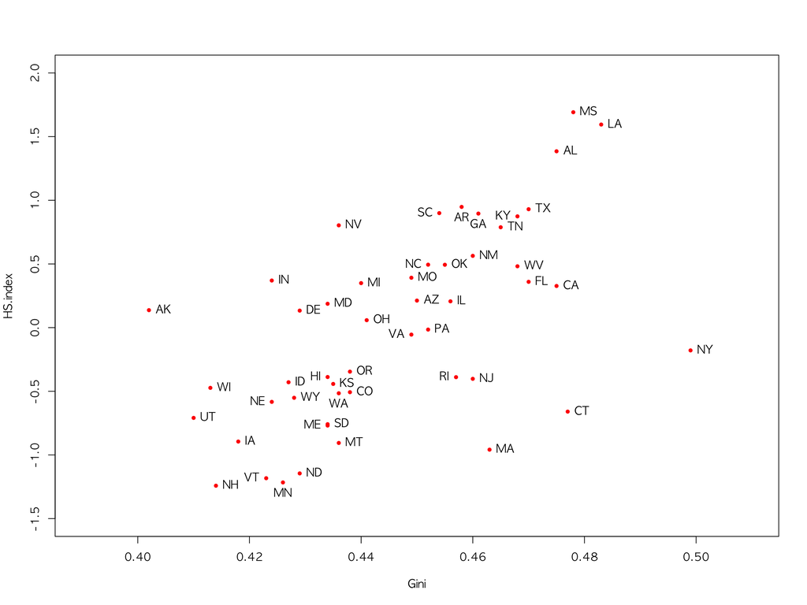

```r
plot(data.usa.1, pch = 20, col = "red", xlim = c(0.39, 0.51), ylim = c(-1.5, 2.0))
text(data.usa.1, labels = Abb, pos = pos.text.us)
```

상관계수를 추가한다.

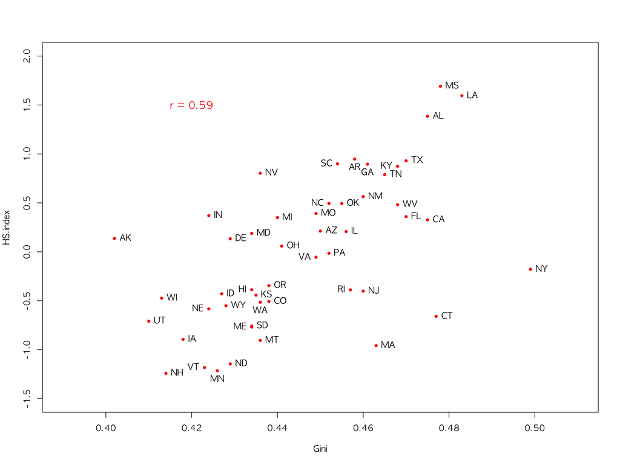

```r
plot(data.usa.1, pch = 20, col = "red", xlim = c(0.39, 0.51), ylim = c(-1.5, 2.0))
text(data.usa.1, labels = Abb, pos = pos.text.us)
cor.us <- cor(data.usa.1$HS.index, data.usa.1$Gini)
text(x = 0.42, y = 1.5, labels = paste("r =", round(cor.us, digits = 2)), col = "red", cex = 1.2)
```

단순회귀선을 추가한다.

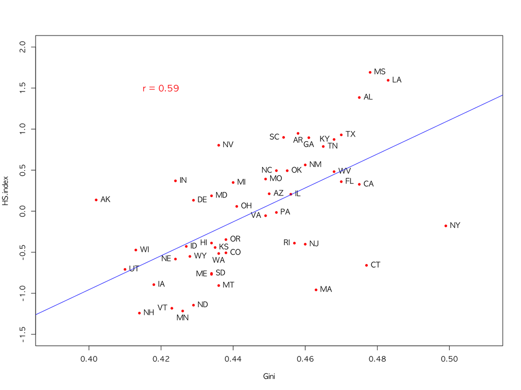

```r
plot(data.usa.1, pch = 20, col = "red", xlim = c(0.39, 0.51), ylim = c(-1.5, 2.0))
text(data.usa.1, labels = Abb, pos = pos.text.us)
text(x = 0.42, y = 1.5, labels = paste("r =", round(cor.us, digits = 2)), col = "red", cex = 1.2)
# lm.ineq.us <- lm(HS.index ~ Gini, data = data.usa.1)
lm.ineq.us <- lm(data.usa.1[2:1])
abline(lm.ineq.us$coef, col = "blue")
```

```r
# abline(lm(HS.index ~ Gini, data = data.usa.1)$coef)
```

주제목을 추가하고, `xlab`, `ylab`을 수정한다. 수직축의 의미를 명확히 한다.

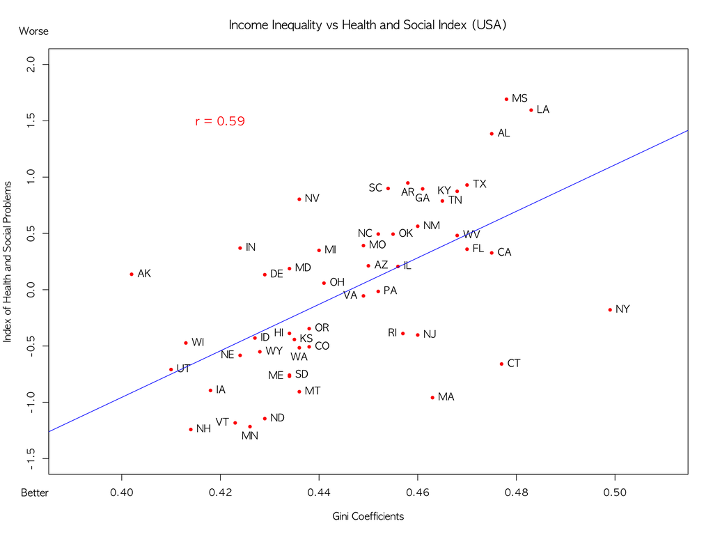

```r
plot(data.usa.1, pch = 20, col = "red", xlim = c(0.39, 0.51), ylim = c(-1.5, 2.0), ann = FALSE)
text(data.usa.1, labels = Abb, pos = pos.text.us)
text(x = 0.42, y = 1.5, labels = paste("r =", round(cor.us, digits = 2)), col = "red", cex = 1.2)
abline(lm.ineq.us$coef, col = "blue")
mtext(c("Better", "Worse"), side = 2, at = c(-1.8, 2.3), las = 1)
main.title.us <- "Income Inequality vs Health and Social Index (USA)"
x.lab.us <- "Gini Coefficients"
y.lab.us <- "Index of Health and Social Problems"
title(main = main.title.us, xlab = x.lab.us, ylab = y.lab.us)
```